# Caso 11

límite de 3 operarios, plazo mes 16, penalización 6 k€/mes y VAN

# Enunciado

Usted dirige la construcción de una planta cuyo cuadro de prelaciones, duraciones (meses; *a*, *m* y *b* son las estimaciones mínima, más probable y máxima de una distribución triangular y *duration* la duración esperada), operarios por actividad, presupuesto (BAC, k€), duración tope y coste unitario de reducción (CUR, k€ por mes) se adjuntan. La cuadrilla fija es de **3 operarios**. Cuando la planta se entrega, genera un flujo neto de 50 k€ al mes durante 36 meses; la empresa descuenta al 10% anual. El viernes recibe estos mensajes.

Tabla 1: Datos del proyecto

| activity | predecessor | duration | a | m | b | operarios | BAC | cap_duration | ucr |
| --- | --- | --- | --- | --- | --- | --- | --- | --- | --- |
| A | --- | 3 | 2 | 3 | 4 | 3 | 175 | 2 | 2.0 |
| B | --- | 1 | 1 | 1 | 1 | 1 | 200 | 1 | inf |
| C | --- | 2 | 1 | 2 | 3 | 3 | 175 | 2 | inf |
| D | A,C | 3 | 1 | 4 | 4 | 1 | 200 | 2 | 4.0 |
| E | B,D | 4 | 3 | 3 | 6 | 2 | 75 | 3 | 9.0 |
| F | C | 5 | 4 | 5 | 6 | 1 | 75 | 5 | inf |
| G | F | 1 | 1 | 1 | 1 | 1 | 200 | 1 | inf |
| H | G | 1 | 1 | 1 | 1 | 2 | 125 | 1 | inf |
| I | E,H | 5 | 3 | 5 | 7 | 2 | 150 | 4 | 8.0 |

> **De: Cliente** El contrato fija la entrega en el mes 16 con una penalización de **6 k€ por mes de retraso**. Les pedimos que nos confirmen la probabilidad real de cumplirlo, no la fecha del plan.

> **De: Director financiero** No autorizaré ninguna medida cuyo VAN esperado, neto de penalizaciones y de lo que cueste, no supere al de no hacer nada. Y quiero saber la probabilidad de que el VAN sea negativo en cada opción.

> **De: Jefe de obra** Podemos subcontratar **un operario más** durante todo el proyecto por 2 k€ al mes. Con la cuadrilla actual, por mucho que acorten las actividades, a veces se quedan esperando por falta de gente.

> **De: Contratista** Podemos acelerar actividades con horas extra y refuerzos a los CUR indicados en la tabla (hasta la duración tope). Díganos cuántos meses necesita recortar y le decimos qué actividades.

Responda a las preguntas siguientes **antes** de decidir. En la penúltima se le pide la decisión y cómo la comunicaría a cada uno de los implicados (cliente, director financiero, jefe de obra, contratista).

1. Calcule la duración con las duraciones esperadas sin límite de recursos y con el límite de operarios. ¿Cuál es la cadena crítica con recursos y qué actividades esperan?

2. Simule 3 000 ejecuciones con duraciones triangulares y con el límite de operarios (replanificando en cada réplica) y estime la probabilidad de entregar en el mes 16, el VAN esperado neto de penalización y P(VAN < 0) si no se hace nada.

3. Evalúe cuatro opciones con los mismos números aleatorios: (A) no hacer nada, (B) contratar un operario más, (C) acelerar dos meses con el contratista (reducción con recursos limitados) y (D) las dos cosas a la vez. Tabla de VAN esperado neto, P(VAN < 0), probabilidad de cumplir el plazo, duración media y coste de la aceleración.

4. ¿Qué opción recomienda al director financiero? ¿Y al cliente? ¿Se suman los efectos de B y C en D? Explique por qué.

5. Redacte en tres o cuatro líneas la respuesta a cada implicado.

6. ¿Qué ha cambiado respecto a un análisis determinista con el camino crítico? Señale al menos tres decisiones que habría tomado mal sin recursos, sin incertidumbre o sin VAN.

# Resolución

## Apartado 1

1. Calcule la duración con las duraciones esperadas sin límite de recursos y con el límite de operarios. ¿Cuál es la cadena crítica con recursos y qué actividades esperan?

Cálculo de los tiempos mínimos y máximos de los nodos del grafo Roy paso a paso. El primer paso muestra el grafo resuelto; a partir del siguiente se calcula desde el principio (avance con los botones):

paso 0 de 24

[figure not shown]

Figura 1: Grafo Roy con las duraciones esperadas y el camino crítico (sin límite de operarios)

Tabla 2: Calendario sin límite de recursos (meses)

[figure not shown]

Haz clic en un número de la tabla para ver cómo se calcula.

👆 **Interactivo:** haz clic en cualquier celda de la tabla para ver cómo se calcula (otro clic la deselecciona).

| Actividad | Duración | Inicio más temprano | Fin más temprano | Inicio más tardío | Fin más tardío | H total | H libre | H independiente |
| --- | --- | --- | --- | --- | --- | --- | --- | --- |
| A | 3 | 0 | 3 | 0 | 3 | 0 | 0 | 0 |
| B | 1 | 0 | 1 | 5 | 6 | 5 | 5 | 5 |
| C | 2 | 0 | 2 | 1 | 3 | 1 | 0 | 0 |
| D | 3 | 3 | 6 | 3 | 6 | 0 | 0 | 0 |
| E | 4 | 6 | 10 | 6 | 10 | 0 | 0 | 0 |
| F | 5 | 2 | 7 | 3 | 8 | 1 | 0 | 0 |
| G | 1 | 7 | 8 | 8 | 9 | 1 | 0 | 0 |
| H | 1 | 8 | 9 | 9 | 10 | 1 | 1 | 0 |
| I | 5 | 10 | 15 | 10 | 15 | 0 | 0 | 0 |

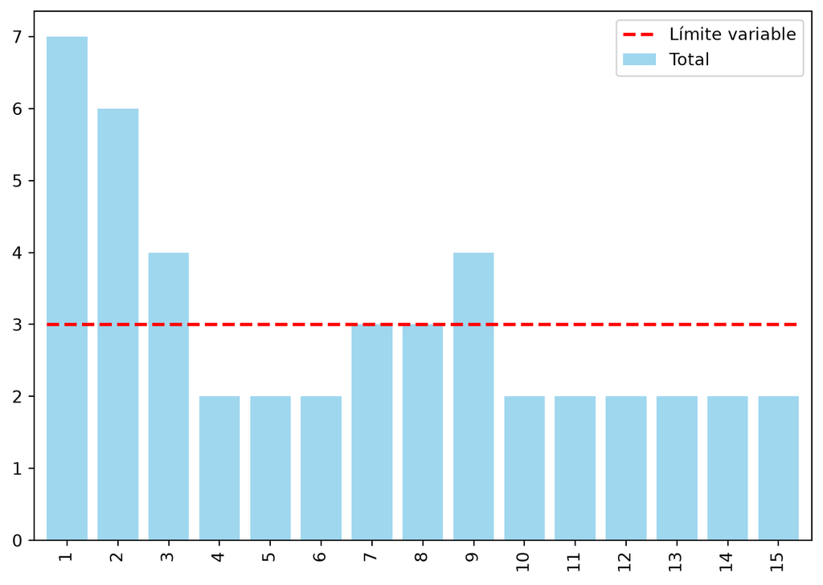

Figura 2: Carga de operarios con los inicios más tempranos frente al límite

El algoritmo de asignación recorre los meses: cada actividad disponible (predecesoras terminadas) empieza, por orden de prioridad (menor inicio más tardío), si caben sus operarios durante toda su duración; si no, espera. Traza mes a mes y Gantt resultante (filas 💤: esperas):

Periodo 1. Empiezan: [‘A’]. Esperan: [‘C (operarios)’, ‘B (operarios)’]

Periodo 2. Empiezan: []. Esperan: [‘C (operarios)’, ‘B (operarios)’]

Periodo 3. Empiezan: []. Esperan: [‘C (operarios)’, ‘B (operarios)’]

Periodo 4. Empiezan: [‘C’]. Esperan: [‘B (operarios)’]

Periodo 5. Empiezan: []. Esperan: [‘B (operarios)’]

Periodo 6. Empiezan: [‘D’, ‘F’, ‘B’]. Esperan: []

Periodo 9. Empiezan: [‘E’]. Esperan: []

Periodo 11. Empiezan: [‘G’]. Esperan: []

Periodo 12. Empiezan: []. Esperan: [‘H (operarios)’]

Periodo 13. Empiezan: [‘H’]. Esperan: []

Periodo 14. Empiezan: [‘I’]. Esperan: []

[figure not shown]

Figura 3: Gantt con el límite de operarios y las duraciones esperadas

Tabla 3: Inicio de cada actividad sin y con límite

|  | A | B | C | D | E | F | G | H | I |
| --- | --- | --- | --- | --- | --- | --- | --- | --- | --- |
| inicio sin límite | 0 | 0 | 0 | 3 | 6 | 2 | 7 | 8 | 10 |
| inicio con límite | 0 | 5 | 3 | 5 | 8 | 5 | 10 | 12 | 13 |
| fin con límite | 3 | 6 | 5 | 8 | 12 | 10 | 11 | 13 | 18 |
| espera (meses) | 0 | 5 | 3 | 0 | 0 | 0 | 0 | 1 | 0 |

|  | de | a | motivo (precedencia o recurso) |
| --- | --- | --- | --- |
| 0 | A | C | recurso |
| 1 | C | D | precedencia |
| 2 | D | E | precedencia |
| 3 | E | H | recurso |
| 4 | H | I | precedencia |

Sin límite 15 meses; con 3 operarios 18. Cadena crítica con recursos: A, C, D, E, H, I. Esperan: B, C, H.

## Apartado 2

2. Simule 3 000 ejecuciones con duraciones triangulares y con el límite de operarios (replanificando en cada réplica) y estime la probabilidad de entregar en el mes 16, el VAN esperado neto de penalización y P(VAN < 0) si no se hace nada.

Sin hacer nada: P(entregar en el mes 16) = 0.121; duración media 18.19 meses; VAN esperado neto 48.0 k€; P(VAN<0) = 0.009.

## Apartado 3

3. Evalúe cuatro opciones con los mismos números aleatorios: (A) no hacer nada, (B) contratar un operario más, (C) acelerar dos meses con el contratista (reducción con recursos limitados) y (D) las dos cosas a la vez. Tabla de VAN esperado neto, P(VAN < 0), probabilidad de cumplir el plazo, duración media y coste de la aceleración.

Las reducciones de C y D se calculan con `crashing_recursos`: en cada paso se programa con el límite, se halla la cadena crítica con recursos, se prueban como candidatos sus actividades reducibles (sueltas, por parejas y el corte de coste mínimo) replanificando con cada uno, y se elige el más barato que de verdad acorta el proyecto replanificado. Paso a paso, con el límite actual (C) y con un operario más (D):

Tabla 4: Crashing con recursos para la opción C (límite actual)

| paso | cadena_critica | ackoff_sin_recursos | candidatos_evaluados | actividades | coste_paso | coste_acumulado | duracion_antes | duracion_despues |
| --- | --- | --- | --- | --- | --- | --- | --- | --- |
| 1 | A, C, D, E, H, I | A | 10 | A | 2.0 | 2.0 | 18 | 17 |
| 2 | A, C, D, E, H, I | I | 6 | D | 4.0 | 6.0 | 17 | 16 |

Tabla 5: Crashing con recursos para la opción D (un operario más)

| paso | cadena_critica | ackoff_sin_recursos | candidatos_evaluados | actividades | coste_paso | coste_acumulado | duracion_antes | duracion_despues |
| --- | --- | --- | --- | --- | --- | --- | --- | --- |
| 1 | A, C, D, E, F, G, H, I | A | 10 | A | 2.0 | 2.0 | 17 | 16 |
| 2 | A, C, D, E, F, G, H, I | I | 6 | D | 4.0 | 6.0 | 16 | 15 |

|  | VAN medio | P(VAN<0) | P(τ≤plazo) | τ medio | coste reducción |
| --- | --- | --- | --- | --- | --- |
| A: no hacer nada | 47.952795 | 0.009000 | 0.120667 | 18.191333 | 0.0 |
| B: un operario más | 18.250230 | 0.200333 | 0.344333 | 17.120667 | 0.0 |
| C: acelerar dos meses | 53.852381 | 0.002000 | 0.424333 | 16.831333 | 6.0 |
| D: operario más y acelerar | 29.349243 | 0.065000 | 0.771667 | 15.470333 | 6.0 |

| activity | A | D |
| --- | --- | --- |
| C: reducciones | 1 | 1 |
| D: reducciones | 1 | 1 |

Las reducciones se calculan con `crashing_recursos`: se acorta lo que de verdad acorta el proyecto con el límite de operarios, no lo más barato.

## Apartado 4

4. ¿Qué opción recomienda al director financiero? ¿Y al cliente? ¿Se suman los efectos de B y C en D? Explique por qué.

Mayor VAN esperado: C: acelerar dos meses (53.9 k€). Opciones con P(cumplir) ≥ 70 %: [‘D: operario más y acelerar’]. Respecto a A, B y C por separado suponen -23.8 k€ en total y juntas (D) -18.6 k€: los efectos no se suman, porque las dos medidas atacan el mismo cuello de botella (esperas por operarios y duración de la cadena crítica).

## Apartado 5

5. Redacte en tres o cuatro líneas la respuesta a cada implicado.

**Cliente:** con la cuadrilla actual la probabilidad de cumplir es baja; la opción recomendada la sube a la cifra de la tabla. **Director financiero:** el VAN esperado neto de penalización y de coste es el de la tabla, con la probabilidad de VAN negativo indicada. **Jefe de obra:** se contrata un operario sólo si la tabla lo respalda; las esperas se concentran en la cadena crítica con recursos. **Contratista:** se aceleran únicamente las actividades que de verdad acortan el proyecto con el límite de operarios.

## Apartado 6

6. ¿Qué ha cambiado respecto a un análisis determinista con el camino crítico? Señale al menos tres decisiones que habría tomado mal sin recursos, sin incertidumbre o sin VAN.

Con el camino crítico y duraciones esperadas se habría dicho que el plazo se cumple (sin límite de recursos y sin incertidumbre); se habría acelerado la actividad más barata aunque no acorte el proyecto; y se habría juzgado cada medida por separado sin ver que se solapan. Los recursos fijan la duración real, la incertidumbre convierte la fecha en una probabilidad y el VAN obliga a comparar el coste de cada medida con lo que vale cobrar antes.